# Primer parcial - Dasometría

### Punto 2

*Para las fincas $0$, $2$ y $4$, analice y grafique (todos los datos en conjunto) la relación entre número de individuos $(ha)$, área basal $(\frac {m^2} {ha})$ y diámetro cuadrático medio $(cm)$. En cuáles casos es significativa la relación? Explique que significa en los casos en que es significativo.*

```r
data1 <- data %>% group_by(Finca, Parcela) %>% summarise(area2= sum((pi/4)*(DAP_cm/100)^2), n= length(Parcela), Dcm= sqrt(mean(DAP_cm^2))) %>%
  mutate('area basal (m2/ha)' = if_else(Finca == "finca3",
                                        area2*10000/2500,
                                        if_else(Finca == "finca4",
                                                area2*10000/2000,
                                                area2*10000/1000)),
         N_individuos= if_else(Finca == "finca3",
                                        n*10000/2500,
                                        if_else(Finca == "finca4",
                                                n*10000/2000,
                                                n*10000/1000)))
```

En la siguiente tabla se muestran los resultados del test de correlación entre las variables. Como se puede apreciar, según sus intervalos de confianza, no hay relación entre $Dcm/Nind$, puesto que el valor del coeficiente no es cercano a -1 o 1. Sin embargo, cabe aclarar que el coeficiente solo indica si hay o no una correlación lineal, lo que significa que las variables si pueden relacionarse. Luego, se observa que para las relaciones $area\ basal/N\ ind$ y $Dcm/area\ basal$, si se obtuvo un mayor grado de asociación, siendo la de mayor valor la relación $area\ basal/N\ ind$.

```r
data2<- data1 %>% filter(Finca == "finca0" | Finca == "finca2" |
                   Finca== "finca4")

a<- cor.test(data2$`area basal (m2/ha)`, data2$N_individuos)
b<- cor.test(data2$Dcm, data2$`area basal (m2/ha)`)
c<- cor.test(data2$Dcm, data2$N_individuos)

rbind(broom::tidy(a) %>% select(estimate, conf.low, conf.high),
broom::tidy(b) %>% select(estimate, conf.low, conf.high),
broom::tidy(c) %>% select(estimate, conf.low, conf.high)) %>% unnest(Cor= c("area_basal/N_ind", "Dcm/area_basal", "Dcm/N_ind"))
```

| estimate | conf.low | conf.high | Cor |
| --- | --- | --- | --- |
| 0.7516675 | 0.6593022 | 0.8216830 | area_basal/N_ind |
| 0.4986992 | 0.3473035 | 0.6247586 | Dcm/area_basal |
| -0.1533420 | -0.3272634 | 0.0306285 | Dcm/N_ind |

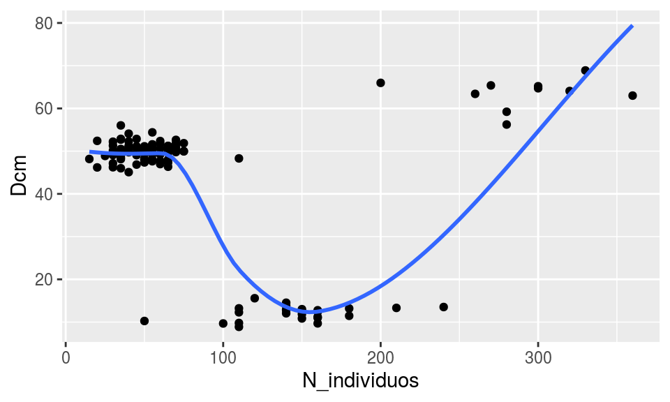

**Fig.3** Relacion $Dcm/N_{ind}$

```r
data1 %>% filter(Finca == "finca0" | Finca == "finca2" |
                   Finca== "finca4") %>%
  ggplot(., mapping = aes(y= Dcm, x= N_individuos)) +
  geom_point() + geom_smooth(se= FALSE)
```

En la **Fig.4** se tiene la relación $área \ basal/Nind$ en esta como en la anterior tabla se tiene una correlación positiva y significativa, lo que sugiere un comportamiento lineal positivo, sin embargo, en la **Fig.4** si bien se observa tal nexo hay una desviación al patrón general, es curioso ver como al principio de la gráfica hay un línea casi perfecta pero después los datos se vuelven diferentes, esto tal vez sea causa de algunos datos atípicos; dado que son bastantes podrìan estos reflejar un comportamiento especial en el terreno como por ejemplo parches en el bosque causando diferentes edades por ende muy diferentes áreas basales. También es importante señalar que esta tendencia ha de deberse a que se realizó una prueba de correlación para tres fincas, lo que puede implicar un sesgo debido a las diferencias estructurales de cada una de estas. Como se mencionó en el primer punto, se observa la correlación negativa para estas dos variables en la finca 4, sin embargo, es de esperarse que al agrupar la información de estas tres fincas la tendencia cambie al igual que el tipo de correlación.

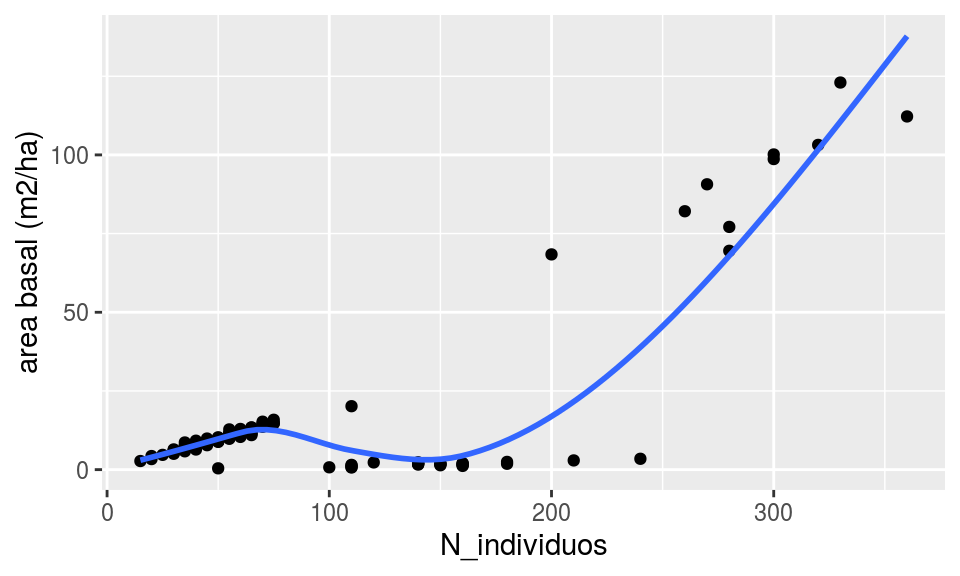

**Fig.4** Relacion $area basal/N_ind$

```r
data1 %>% filter(Finca == "finca0" | Finca == "finca2" |
                   Finca== "finca4") %>%
  ggplot(., mapping = aes(y= `area basal (m2/ha)`, x= N_individuos)) +
  geom_point() + geom_smooth(se= FALSE)
```

En la **Fig.5** pasa algo parecido a lo anterior descrito, pero aquí, la relación en “trozos” es muy marcada sugiriendo un comportamiento lineal pero a pedazos donde la pendiente en un principio es alta ,es decir, la tasa de cambio entre $area \ basal$ y $Dcm$ es muy rápida llega un punto donde está pendiente baja considerablemente y dado la densidad de puntos allí encontrados sugiere que árboles con DAP altos son pocos pues su medida de ocupación es “pobre” en comparación con los de $DAP$ bajo.

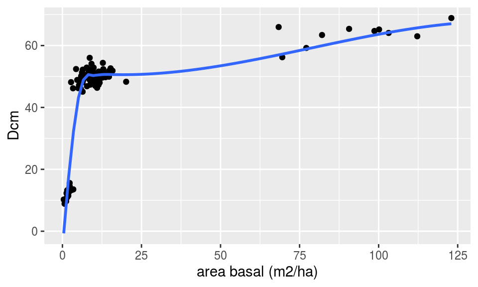

**Fig.5** Relacion $Dcm/area basal$

```r
data1 %>% filter(Finca == "finca0" | Finca == "finca2" |
                   Finca== "finca4") %>%
  ggplot(., mapping = aes(x= `area basal (m2/ha)`, y= Dcm)) +
  geom_point() + geom_smooth(se= FALSE)
```